# Guia 2

Grupo 3: Emiliano Bodean - Zacarias Ojeda

10/19/2019

# Guía 2

## Ejercicio 1

### Resolución del problema XOR con una red neuronal RBF

- Lectura de los patrones de entrenamiento

```r
XOR_trn <- read_csv("../../PUBLICO/Encuentro 1/Práctica/data/XOR_trn.csv", col_names = FALSE)
XOR_tst <- read_csv("../../PUBLICO/Encuentro 1/Práctica/data/XOR_tst.csv", col_names = FALSE)
```

- Selección de parámetros y entrenamiento de perceptrón

En este caso se utilizan 4 gausianas por la distribución de los datos.

```r
datos_x <- XOR_trn[,c(1,2)]
datos_y <- XOR_trn[,3]
modeloRBF <- redRBF(datos_x, datos_y, nroGausianas = 4, funcion = "sigmo")
```

```
## Epoca: 1 - Tasa: 0.7545 - Error: 0.974498913725511
## Epoca: 2 - Tasa: 1 - Error: 0.818030231536048
```

- Prueba con datos de test

```r
datos_x <- XOR_tst[,c(1,2)]
datos_y <- XOR_tst[,3]
salida <- aplicarRedRBF(modeloRBF, datos_x, datos_y)
salida$tasa
```

```
## [1] 1
```

### Resolución del problema Iris con una red neuronal RBF

- Lectura de los patrones de entrenamiento

```r
irisbin <- read_csv("../../PUBLICO/Encuentro 1/Práctica/data/irisbin.csv", col_names = FALSE)
```

- Selección de parámetros y entrenamiento de perceptrón

```r
datos_x <- irisbin[,c(1,2,3,4)]
datos_y <- irisbin[,c(5,6,7)]

modeloRBF <- redRBF(datos_x, datos_y, nroGausianas = 10, funcion = "sigmo", pnu = 0.2,
                    pepoca = 200, pcritFinalizacion = 0.9)
```

```
## Epoca: 1 - Tasa: 0.7 - Error: 0.899307224708706
## Epoca: 2 - Tasa: 0.7 - Error: 0.868410270391567
## Epoca: 3 - Tasa: 0.7 - Error: 0.866871585990492
## Epoca: 4 - Tasa: 0.7 - Error: 0.865365830685227
## Epoca: 5 - Tasa: 0.7 - Error: 0.863862560324871
## Epoca: 6 - Tasa: 0.7 - Error: 0.862361631295195
## Epoca: 7 - Tasa: 0.7 - Error: 0.86086308739289
## Epoca: 8 - Tasa: 0.7 - Error: 0.859366972691919
## Epoca: 9 - Tasa: 0.7 - Error: 0.857873330386743
## Epoca: 10 - Tasa: 0.7 - Error: 0.856382202791228
## Epoca: 11 - Tasa: 0.7 - Error: 0.854893631344791
## Epoca: 12 - Tasa: 0.7 - Error: 0.853407656618756
## Epoca: 13 - Tasa: 0.7 - Error: 0.851924318322879
## Epoca: 14 - Tasa: 0.7 - Error: 0.850443655312023
## Epoca: 15 - Tasa: 0.7 - Error: 0.848965705592982
## Epoca: 16 - Tasa: 0.7 - Error: 0.847490506331451
## Epoca: 17 - Tasa: 0.7 - Error: 0.846018093859115
## Epoca: 18 - Tasa: 0.7 - Error: 0.844548503680881
## Epoca: 19 - Tasa: 0.7 - Error: 0.843081770482209
## Epoca: 20 - Tasa: 0.7 - Error: 0.841617928136572
## Epoca: 21 - Tasa: 0.7 - Error: 0.840157009713005
## Epoca: 22 - Tasa: 0.7 - Error: 0.838699047483764
## Epoca: 23 - Tasa: 0.7 - Error: 0.837244072932066
## Epoca: 24 - Tasa: 0.7 - Error: 0.835792116759923
## Epoca: 25 - Tasa: 0.7 - Error: 0.834343208896048
## Epoca: 26 - Tasa: 0.7 - Error: 0.832897378503836
## Epoca: 27 - Tasa: 0.7 - Error: 0.831454653989417
## Epoca: 28 - Tasa: 0.7 - Error: 0.830015063009759
## Epoca: 29 - Tasa: 0.7 - Error: 0.828578632480842
## Epoca: 30 - Tasa: 0.7 - Error: 0.827145388585867
## Epoca: 31 - Tasa: 0.7 - Error: 0.825715356783524
## Epoca: 32 - Tasa: 0.7 - Error: 0.824288561816291
## Epoca: 33 - Tasa: 0.7 - Error: 0.822865027718773
## Epoca: 34 - Tasa: 0.7 - Error: 0.82144477782607
## Epoca: 35 - Tasa: 0.7 - Error: 0.820027834782174
## Epoca: 36 - Tasa: 0.7 - Error: 0.818614220548383
## Epoca: 37 - Tasa: 0.7 - Error: 0.817203956411737
## Epoca: 38 - Tasa: 0.7 - Error: 0.815797062993462
## Epoca: 39 - Tasa: 0.7 - Error: 0.81439356025743
## Epoca: 40 - Tasa: 0.7 - Error: 0.812993467518617
```

[output cut: 414 more lines]

```
## Epoca: 55 - Tasa: 0.586666666666667 - Error: 0.678005724546121
## Epoca: 56 - Tasa: 0.586666666666667 - Error: 0.673605784152759
## Epoca: 57 - Tasa: 0.586666666666667 - Error: 0.66924392477679
## Epoca: 58 - Tasa: 0.586666666666667 - Error: 0.664919911956726
## Epoca: 59 - Tasa: 0.686666666666667 - Error: 0.660633507466958
## Epoca: 60 - Tasa: 0.686666666666667 - Error: 0.656384469551298
## Epoca: 61 - Tasa: 0.72 - Error: 0.652172553149572
## Epoca: 62 - Tasa: 0.753333333333333 - Error: 0.6479975101174
## Epoca: 63 - Tasa: 0.84 - Error: 0.643859089439266
## Epoca: 64 - Tasa: 0.84 - Error: 0.639757037435019
## Epoca: 65 - Tasa: 0.866666666666667 - Error: 0.635691097959922
## Epoca: 66 - Tasa: 0.866666666666667 - Error: 0.631661012598356
## Epoca: 67 - Tasa: 0.893333333333333 - Error: 0.627666520851326
## Epoca: 68 - Tasa: 0.9 - Error: 0.623707360317874
## Epoca: 69 - Tasa: 0.906666666666667 - Error: 0.619783266870521
```

Utilizamos un k alto porque trabajamos solo con gausianas circulares unitarias y queremos representar cada clase con más de una gausiana.

- Prueba con datos

```r
salida <- aplicarRedRBF(modeloRBF, datos_x, datos_y)
salida$tasa
```

```
## [1] 0.94
```

```r
head(salida$salida)
```

```
##    1  1  1
## 1 -1 -1  1
## 2 -1 -1  1
## 3  1 -1 -1
## 4 -1 -1  1
## 5  1 -1 -1
## 6  1 -1 -1
```

Cantidad de parámetros:

En una red MLP con una estructura (4,3,3), tenemos los siguientes parámetros:

$numParamMLP = Parámetros de Capa 1 + Parámetros de Capa 2 + Parámetros de Capa 3$

$numParamMLP = [(4 entradas + 1) * 4 neuronas] + [(4 entradas + 1) * 3 neurona] + [(3 entradas + 1) * 3 neurona]$

$numParamMLP = 5 * 4 + 5 * 3 + 4 * 3 = 47 parámetros$

Una red RBF para el mismo problema podría tener la siguiente distribución:

$numParamRBF = Parámetros de Gausianas + Parámetros de Perceptrones$

$numParamRBF = [3 centros] + [(3 entradas + 1) * 3 neurona]$

$numParamRBF = 3 + 4 * 3 = 15 parámetros$

```r
modeloRBF_2 <- redRBF(datos_x, datos_y, nroGausianas = 3, funcion = "sigmo", pnu = 0.2,
                    pepoca = 200, pcritFinalizacion = 0.9)
```

```
## Epoca: 1 - Tasa: 0.7 - Error: 0.889902819718957
## Epoca: 2 - Tasa: 0.7 - Error: 0.860691712514331
## Epoca: 3 - Tasa: 0.7 - Error: 0.860007594271546
## Epoca: 4 - Tasa: 0.7 - Error: 0.859350609550805
## Epoca: 5 - Tasa: 0.7 - Error: 0.858694177395873
## Epoca: 6 - Tasa: 0.7 - Error: 0.858038149457409
## Epoca: 7 - Tasa: 0.7 - Error: 0.857382528694433
## Epoca: 8 - Tasa: 0.7 - Error: 0.856727318912102
## Epoca: 9 - Tasa: 0.7 - Error: 0.856072523893069
## Epoca: 10 - Tasa: 0.7 - Error: 0.855418147392553
## Epoca: 11 - Tasa: 0.7 - Error: 0.854764193138352
## Epoca: 12 - Tasa: 0.7 - Error: 0.8541106648309
## Epoca: 13 - Tasa: 0.7 - Error: 0.853457566143311
## Epoca: 14 - Tasa: 0.7 - Error: 0.852804900721436
## Epoca: 15 - Tasa: 0.7 - Error: 0.85215267218391
## Epoca: 16 - Tasa: 0.7 - Error: 0.85150088412221
## Epoca: 17 - Tasa: 0.7 - Error: 0.850849540100708
## Epoca: 18 - Tasa: 0.7 - Error: 0.850198643656726
## Epoca: 19 - Tasa: 0.7 - Error: 0.849548198300596
## Epoca: 20 - Tasa: 0.7 - Error: 0.848898207515714
## Epoca: 21 - Tasa: 0.7 - Error: 0.848248674758601
## Epoca: 22 - Tasa: 0.7 - Error: 0.847599603458965
## Epoca: 23 - Tasa: 0.7 - Error: 0.846950997019757
## Epoca: 24 - Tasa: 0.7 - Error: 0.846302858817236
## Epoca: 25 - Tasa: 0.7 - Error: 0.845655192201031
## Epoca: 26 - Tasa: 0.7 - Error: 0.845008000494205
## Epoca: 27 - Tasa: 0.7 - Error: 0.844361286993322
## Epoca: 28 - Tasa: 0.7 - Error: 0.843715054968505
## Epoca: 29 - Tasa: 0.7 - Error: 0.843069307663513
## Epoca: 30 - Tasa: 0.7 - Error: 0.842424048295799
## Epoca: 31 - Tasa: 0.7 - Error: 0.841779280056583
## Epoca: 32 - Tasa: 0.7 - Error: 0.841135006110919
## Epoca: 33 - Tasa: 0.7 - Error: 0.840491229597769
## Epoca: 34 - Tasa: 0.7 - Error: 0.839847953630066
## Epoca: 35 - Tasa: 0.7 - Error: 0.839205181294792
## Epoca: 36 - Tasa: 0.7 - Error: 0.838562915653048
## Epoca: 37 - Tasa: 0.7 - Error: 0.837921159740126
## Epoca: 38 - Tasa: 0.7 - Error: 0.837279916565583
## Epoca: 39 - Tasa: 0.7 - Error: 0.836639189113318
## Epoca: 40 - Tasa: 0.7 - Error: 0.835998980341642
```

[output cut: 527 more lines]

```
## Epoca: 168 - Tasa: 0.84 - Error: 0.634215717505276
## Epoca: 169 - Tasa: 0.84 - Error: 0.632578971806015
## Epoca: 170 - Tasa: 0.84 - Error: 0.630948021632
## Epoca: 171 - Tasa: 0.84 - Error: 0.629322850510039
## Epoca: 172 - Tasa: 0.84 - Error: 0.627703441909247
## Epoca: 173 - Tasa: 0.873333333333333 - Error: 0.626089779242975
## Epoca: 174 - Tasa: 0.873333333333333 - Error: 0.62448184587073
## Epoca: 175 - Tasa: 0.873333333333333 - Error: 0.622879625100055
## Epoca: 176 - Tasa: 0.9 - Error: 0.621283100188395
## Epoca: 177 - Tasa: 0.9 - Error: 0.619692254344928
## Epoca: 178 - Tasa: 0.9 - Error: 0.618107070732384
## Epoca: 179 - Tasa: 0.9 - Error: 0.616527532468827
## Epoca: 180 - Tasa: 0.9 - Error: 0.614953622629421
## Epoca: 181 - Tasa: 0.9 - Error: 0.61338532424817
## Epoca: 182 - Tasa: 0.906666666666667 - Error: 0.611822620319634
```

- Prueba con datos

```r
salida_2 <- aplicarRedRBF(modeloRBF_2, datos_x, datos_y)
salida_2$tasa
```

```
## [1] 0.7133333
```

```r
head(salida_2$salida)
```

```
##    1  1  1
## 1 -1 -1  1
## 2 -1 -1  1
## 3  1 -1 -1
## 4 -1 -1  1
## 5  1 -1 -1
## 6  1 -1 -1
```

Para este problema en particular, un modelo basado en redes de base radial permite obtener un buen porcentaje de aciertos con un menor tiempo de cálculo ya que requiere menos parámetros que la red MLP.

## Ejercicio 2

- Lectura de datos

```r
merval <- read_csv("../../PUBLICO/Encuentro 3/Práctica/data/merval.csv", col_names = FALSE)
```

- Preprocesamiento de los datos

Generamos un dataset que contenga seis valores consecutivos en cada registro, cinco tomados como datos de entrada y un sexto valor tomado como clase.

```r
cantidadDatos <- nrow(merval)
datos_merval <- matrix(0,nrow = cantidadDatos-5, ncol = 6)

for (i in seq(1,cantidadDatos-5)) {
  datos_merval[i,] <- merval$X1[seq(i,i+5)]
}

datos_x <- datos_merval[,c(1,2,3,4,5)] %>% as.matrix()
datos_y <- datos_merval[,6] %>% as.matrix()

# Primeros seis registros del dataset
head(datos_merval)
```

```
##      [,1] [,2] [,3] [,4] [,5] [,6]
## [1,]  215  212  229  253  254  235
## [2,]  212  229  253  254  235  239
## [3,]  229  253  254  235  239  241
## [4,]  253  254  235  239  241  252
## [5,]  254  235  239  241  252  253
## [6,]  235  239  241  252  253  257
```

Antes de generar el modelo, tenemos que definir el número de gausianas. Utilizamos la gráfica de Elbow para definir el k a utilizar en el modelo.

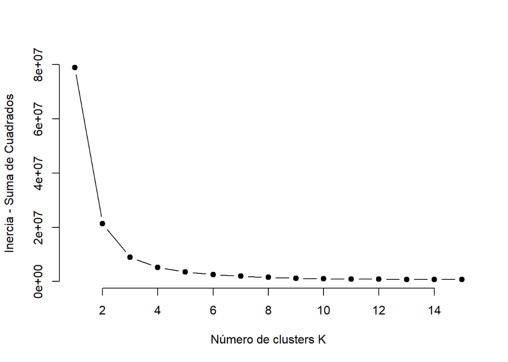

```r
set.seed(123)
wss <- function(k) {
  kmeans(datos_x, k, nstart = 10 )$tot.withinss
}
# Valores de k = 1 a k = 15
k.values <- 1:15
wss_values <- map_dbl(k.values, wss)
plot(k.values, wss_values,
       type="b", pch = 19, frame = FALSE,
       xlab="Número de clusters K",
       ylab="Inercia - Suma de Cuadrados")
```

Mirando la gráfica anterior tomamos un valor de k = 4, es donde la gráfica hace el codo y queda aproximadamente constante.

- Normalizamos los datos.

```r
maximo <- 0
for (i in seq(1,ncol(datos_x))) {
  if (max(datos_x[,i]) > maximo) {maximo <- max(datos_x[,i])}
}
if (max(datos_y) > maximo) {maximo <- max(datos_y)}

datos_x <- datos_x / maximo
datos_y <- datos_y / maximo
```

- Dividimos los datos en Train y Test, utilizando un 70% para entrenamiento.

```r
merval7030 <- generarParticionPorID(as.data.frame(datos_merval), porcEntrenamiento = 0.7,
                                    semilla = 1, clase = "V6")
```

- Generamos el modelo con los datos de entrenamiento.

```r
if (calcular) {
modeloMerval70 <- redRBF(datos_x[merval7030$trn,], (datos_y[merval7030$trn,] %>% as.matrix()),
                         nroGausianas = 4, funcion = "lineal", pnu = 0.01, pepoca = 200000,
                         pcritFinalizacion = 0.95, ptolerencia = 0.1)
}
```

- Aplicamos el modelo a los datos de Train y Test

```r
salidaMervalTrn <- aplicarRedRBF(modeloMerval70, datos_x[merval7030$trn,],
                                 (datos_y[merval7030$trn,] %>% as.matrix()))
salidaMervalTst <- aplicarRedRBF(modeloMerval70, datos_x[merval7030$tst,],
                                 (datos_y[merval7030$tst,] %>% as.matrix()))
```

- Grafica de error en Test

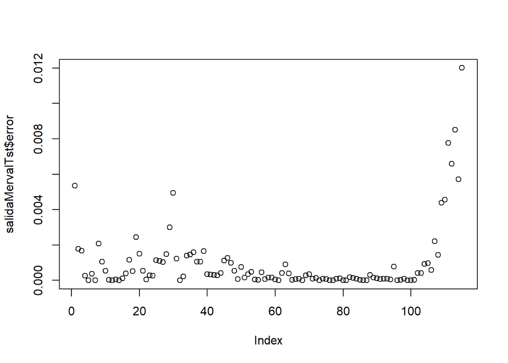

```r
#Grafica de error en cada registro
plot(salidaMervalTst$error)
```

```r
#Error cuadrático medio
errorMedio <- sum(salidaMervalTst$error) / length(salidaMervalTst$error)
errorMedio
```

```
## [1] 0.0009814814
```

- Generamos el modelo a aplicar para realizar las predicciones con todos los datos.

```r
# Generamos el modelo
if (calcular) {
modeloMerval <- redRBF(datos_x, datos_y, nroGausianas = 4, funcion = "lineal", pnu = 0.01,
                    pepoca = 200000, pcritFinalizacion = 0.95, ptolerencia = 0.1)
}
```

Aplicamos el modelo a los mismos datos de entrenamiento para graficar error en train.

```r
salidaMerval <- aplicarRedRBF(modeloMerval, datos_x, datos_y)
```

Grafica de error

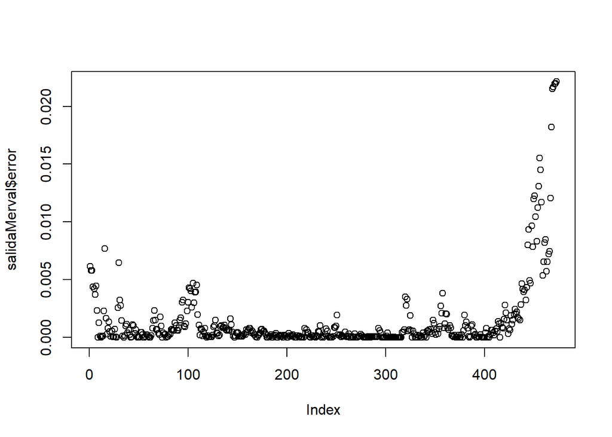

```r
#Grafica de error en cada registro
plot(salidaMerval$error)
```

```r
#Error cuadrático medio
errorMedio <- sum(salidaMerval$error) / length(salidaMerval$error)
errorMedio
```

```
## [1] 0.001437009
```

- Gráfica del valor predicho y el valor real

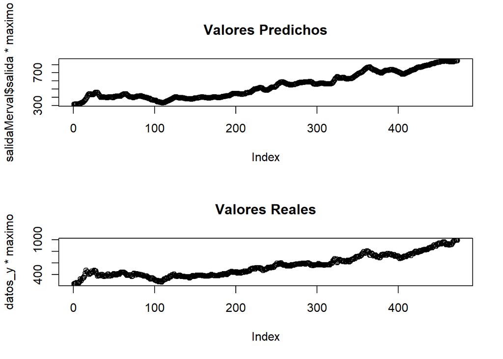

```r
par(mfrow=c(2,1))
plot(salidaMerval$salida * maximo, main = "Valores Predichos")
plot(datos_y * maximo, main = "Valores Reales")
```

- Predecimos un nuevo valor

Tomamos los últimos 5 valores del dataset y predecimos cual será el próximo valor.

```r
ultimosDatos <- (merval[seq(nrow(merval)-4,nrow(merval)),] / maximo) %>% as.matrix()
ultimosDatos <- t(ultimosDatos)
ultimosDatos <- rbind(ultimosDatos,ultimosDatos) %>% as.matrix()
#usamos dos registros por el tipo de datos.
salidaUno <- as.matrix(c(1,1))
salidaMervalNew <- aplicarRedRBF(modeloMerval, ultimosDatos, salidaUno)
#Nuevo valor predicho
salidaMervalNew$salida[1] * maximo
```

```
##       X1
## 851.0265
```

```r
# Guardamos los modelos generados
if (calcular) {
save(modeloMerval, modeloMerval70,file = "resultadosG2.RData")
}
```

## Ejercicio 3

- Lectura de datos

```r
circulo <- read_csv("../../PUBLICO/Encuentro 3/Práctica/data/circulo.csv", col_names = FALSE)
te <- read_csv("../../PUBLICO/Encuentro 3/Práctica/data/te.csv", col_names = FALSE)
```

- Graficamos los datos de entrada

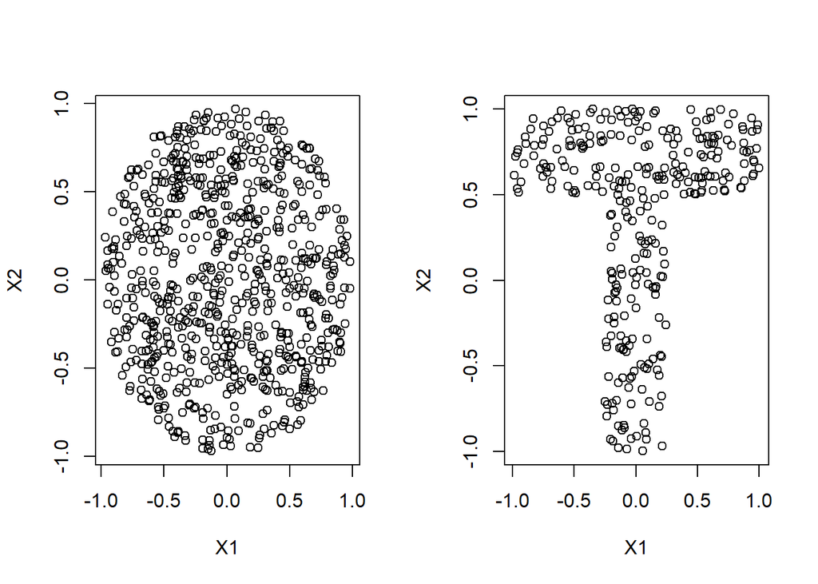

```r
par(mfrow=c(1,2))
plot(circulo)
plot(te)
```

- Inicialización de Grilla SOM

Implementamos una función con dos casos, una red cuadrada y una red lineal.

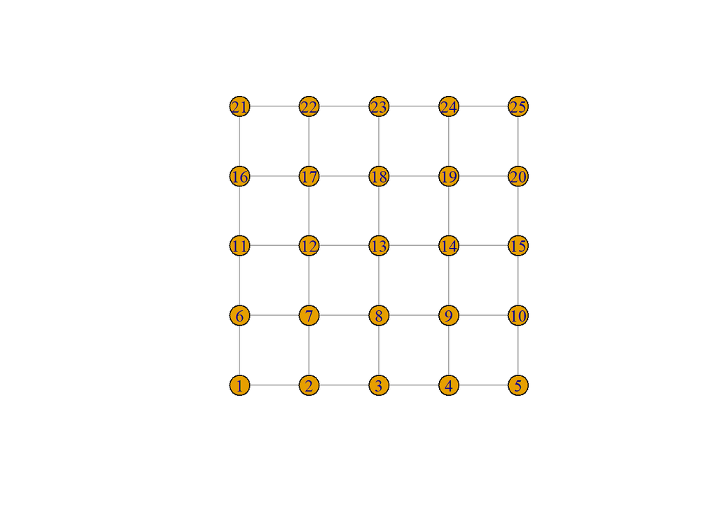

```r
# Definimos la cantidad de nodos.
# El parámetro es la cantidad de nodos a lo ancho/largo de la grilla

inicializarGrilla <- function(cantidadNodos, forma = "cuadrada") {
  if(forma == "cuadrada") {
    # Defino conexiones entre puntos
    g <- make_lattice( c(cantidadNodos,cantidadNodos) )
    # Defino la ubicación de los puntos en el gráfico
    # Se distribuyen en un cuadrado de 1 por 1 para trabajar con datos normalizados.
    miLayout <- c(rep(seq(0,cantidadNodos-1),cantidadNodos))
    for (i in seq(0,cantidadNodos-1)) {
      miLayout <- c(miLayout,rep(i,cantidadNodos))
    }
    miLayout <- matrix(miLayout, ncol = 2, nrow = cantidadNodos * cantidadNodos)
    miLayout <- ((miLayout / cantidadNodos) * 2 ) - 1
    # Generamos el gráfico
    plot(g, layout=miLayout)
  }
  if(forma == "lineal") {
    # Defino conexiones entre puntos
    g <- make_lattice( c(cantidadNodos) )
    # Defino la ubicación de los puntos en el gráfico
    # Se distribuyen en un cuadrado de 1 por 1 para trabajar con datos normalizados.
    miLayout <- c(seq(0,cantidadNodos-1),rep(0,cantidadNodos))
    miLayout <- matrix(miLayout, ncol = 2, nrow = cantidadNodos)
    miLayout[,1] <- ((miLayout / cantidadNodos) * 2 )[,1] - 1
    # Generamos el gráfico
    plot(g, layout=miLayout)
  }
  return(list(miLayout = miLayout, g = g))
}

cantidadNodos <- 5
grillaSOM <- inicializarGrilla(cantidadNodos, forma = "cuadrada")
```

```r
g        <- grillaSOM$g
miLayout <- grillaSOM$miLayout
```

- Función de vecindad

Implementamos una función vecindad. Devuelve los ID de los vecinos de un nodo en un entorno cuadrado.

```r
vecindad <- function(nodo, g, entorno = 1) {
  vecinos <- which(g[nodo]==1)
  if(entorno > 1) {
    for (n in seq(1,entorno-1)) {
      vecinosAux <- which(apply(g[vecinos] %>% as.matrix(), 2, sum) != 0)
      vecinos <- unique(c(vecinos,vecinosAux))
    }
  }
  vecinos = unique(c(vecinos,nodo))
  return(vecinos)
}

#vecindad(nodo = 45, g, entorno = 2)
```

- Entrenamiento de la res SOM - Circulo

Implementamos la función de entrenamiento para redes SOM, y se la utiliza en el caso del Circulo.

La función dentro tiene tres etapas,

- Ordenamiento topológico o global
- Transición
- Ajuste fino

La vecindad para el ajuste de los pesos decrece en forma lineal hasta 1 y la taza de aprendizaje decrece linealmente hasta 0,05.

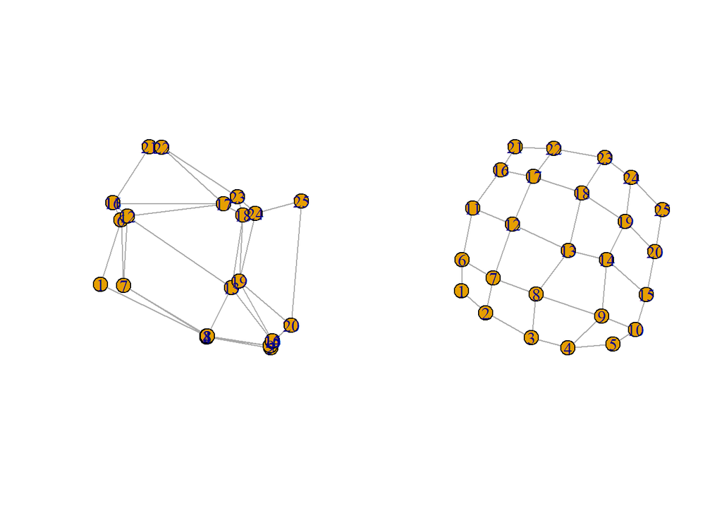

```r
entrenemientoSOM <- function(datos, nu = 0.9, cantidadEpocas = 100, g, miLayout,
                             cantidadNodos, entorno, criterioSalida = 0.001) {
  cantidadDatos <- nrow(datos)
  graficas <- list()
  # 1) Ordenamiento topológico o global
  for (e in seq(1,cantidadEpocas)) {
    #Hacemos un for para recorrer todos los datos de entrada
    for (i in seq(1,cantidadDatos)) {
      # para cada valor recorremos la red SOM y buscamos la distancia menor
      aux_1  <- (datos[i,1] %>% as.numeric()) - miLayout[,1]
      aux_2  <- (datos[i,2] %>% as.numeric()) - miLayout[,2]
      aux_1  <- (aux_1)^2
      aux_2  <- (aux_2)^2
      aux2 <- sqrt( aux_1 + aux_2 )
      distMenor <- min(aux2)
      nodoGanador <- which(aux2 == min(aux2))[1]

      #ajustar los pesos de la neurona ganadora y las neuronas vecinas
      # 1) Ordenamiento topológico o global
      if(e < cantidadEpocas/15) {
        vecinos <- vecindad(nodo = nodoGanador, g, entorno = entorno)
        for (k in vecinos) {
          miLayout[k,] <- (miLayout[k,] + nu * (datos[i,] - miLayout[k,])) %>% as.numeric()
        }
      } else {
          # 2) Transicion
          if(e < (10*cantidadEpocas/15)) {
            vecinos <- vecindad(nodo = nodoGanador, g, entorno = entorno)
            for (k in vecinos) {
              miLayout[k,] <- (miLayout[k,] + nu * (datos[i,] - miLayout[k,])) %>% as.numeric()
            }
            entorno <- max(entorno - 1, 1)
            nu <- max(nu - 0.05, 0.05)
          } else {
            # 3) Ajuste fino
            nu <- 0.05
            entorno <- 1
            vecinos <- vecindad(nodo = nodoGanador, g, entorno = entorno)
            for (k in vecinos) {
              miLayout[k,] <- (miLayout[k,] + nu * (datos[i,] - miLayout[k,])) %>% as.numeric()
            }
          }
        }
    }

    #if(((e%%5)==0)|e==1|e==2) {  #hacemos un dibujo cada 5 épocas
    if(TRUE) {  #hacemos un dibujo cada época
      plot(g, layout=miLayout)
      print("Epoca")
      print(e)
      graficas[[e]] <- list(g=g,miLayout=miLayout)
    }
  }
  return(list(graficas = graficas, milayout=miLayout, g=g, epocas = e))
}

datos <- circulo
nu <- 0.4
cantidadEpocas <- 30
entorno <- 3

if (calcular) {
  modeloCirculo <- entrenemientoSOM(datos, nu, cantidadEpocas, g, miLayout,
                                    cantidadNodos, entorno)
}

# Graficas:
par(mfrow=c(1,2))
plot(modeloCirculo$graficas[[1]]$g, layout=modeloCirculo$graficas[[1]]$miLayout)
plot(modeloCirculo$graficas[[2]]$g, layout=modeloCirculo$graficas[[2]]$miLayout)
```

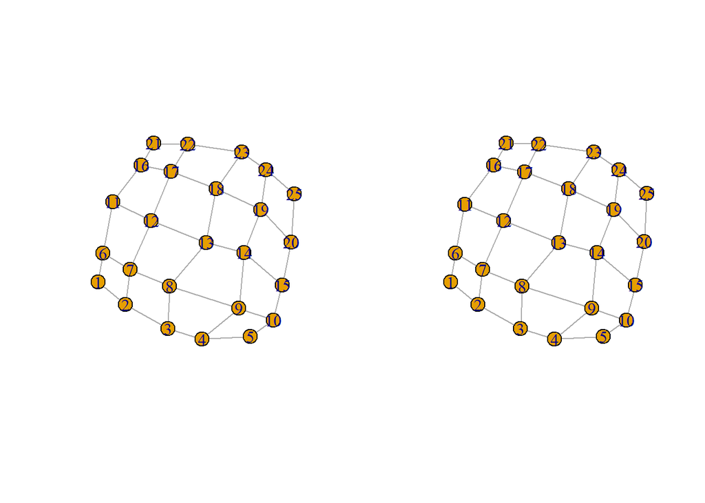

```r
par(mfrow=c(1,2))
plot(modeloCirculo$graficas[[3]]$g, layout=modeloCirculo$graficas[[3]]$miLayout)
plot(modeloCirculo$graficas[[5]]$g, layout=modeloCirculo$graficas[[5]]$miLayout)
```

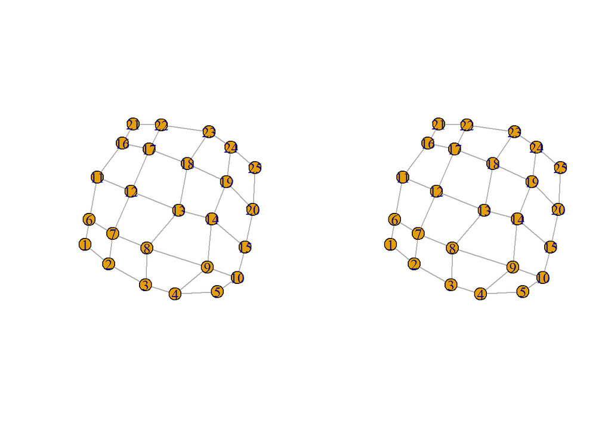

```r
par(mfrow=c(1,2))
plot(modeloCirculo$graficas[[10]]$g, layout=modeloCirculo$graficas[[10]]$miLayout)
plot(modeloCirculo$graficas[[15]]$g, layout=modeloCirculo$graficas[[15]]$miLayout)
```

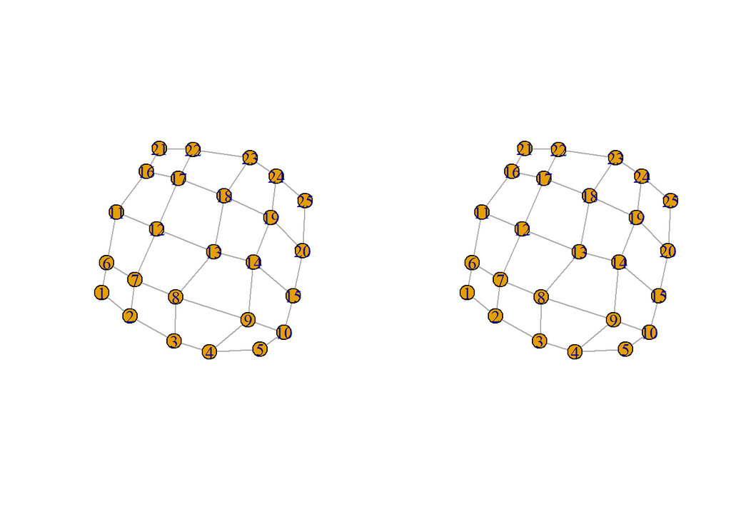

```r
par(mfrow=c(1,2))
plot(modeloCirculo$graficas[[20]]$g, layout=modeloCirculo$graficas[[20]]$miLayout)
plot(modeloCirculo$graficas[[25]]$g, layout=modeloCirculo$graficas[[25]]$miLayout)
```

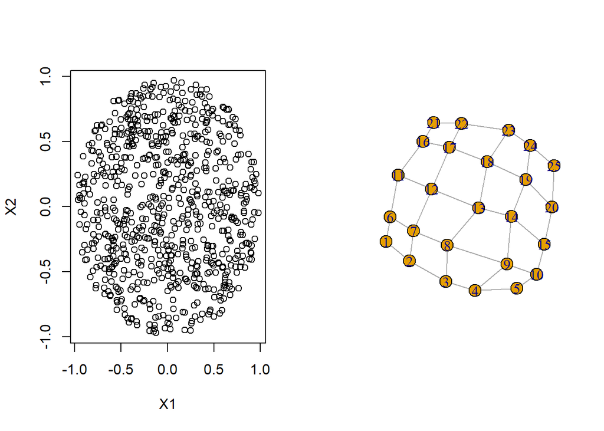

```r
par(mfrow=c(1,2))
plot(circulo)
plot(modeloCirculo$graficas[[modeloCirculo$epocas]]$g,
     layout=modeloCirculo$graficas[[modeloCirculo$epocas]]$miLayout)
```

- Inicialización de Grilla SOM - Te

```r
cantidadNodos <- 5
grillaSOM <- inicializarGrilla(cantidadNodos, forma = "cuadrada")
```

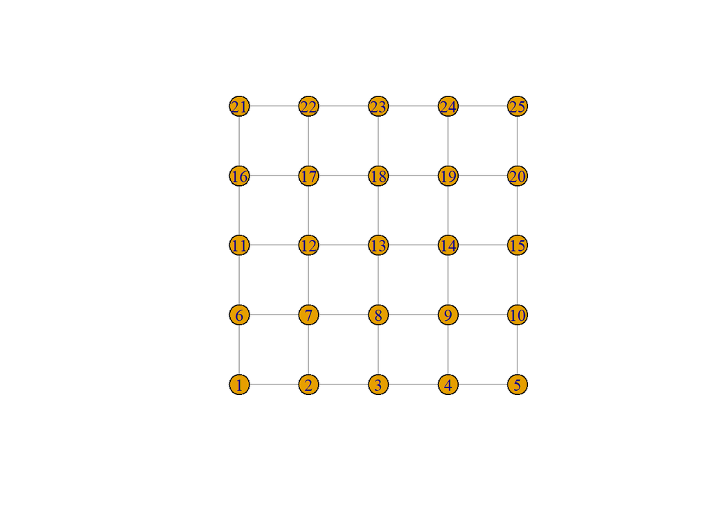

```r
g        <- grillaSOM$g
miLayout <- grillaSOM$miLayout
```

- Entrenamiento de la res SOM - Te

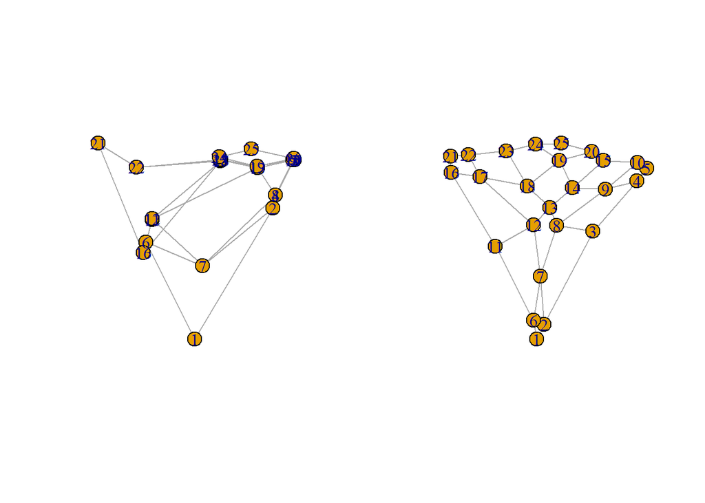

```r
datos <- te
nu <- 0.4
cantidadEpocas <- 30
entorno <- 3

if (calcular) {
  modeloTe <- entrenemientoSOM(datos, nu, cantidadEpocas, g, miLayout,
                               cantidadNodos, entorno)
}

# Graficas:
par(mfrow=c(1,2))
plot(modeloTe$graficas[[1]]$g, layout=modeloTe$graficas[[1]]$miLayout)
plot(modeloTe$graficas[[2]]$g, layout=modeloTe$graficas[[2]]$miLayout)
```

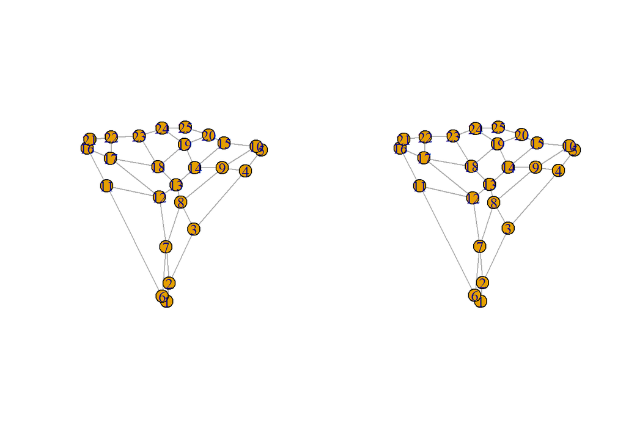

```r
par(mfrow=c(1,2))
plot(modeloTe$graficas[[3]]$g, layout=modeloTe$graficas[[3]]$miLayout)
plot(modeloTe$graficas[[5]]$g, layout=modeloTe$graficas[[5]]$miLayout)
```

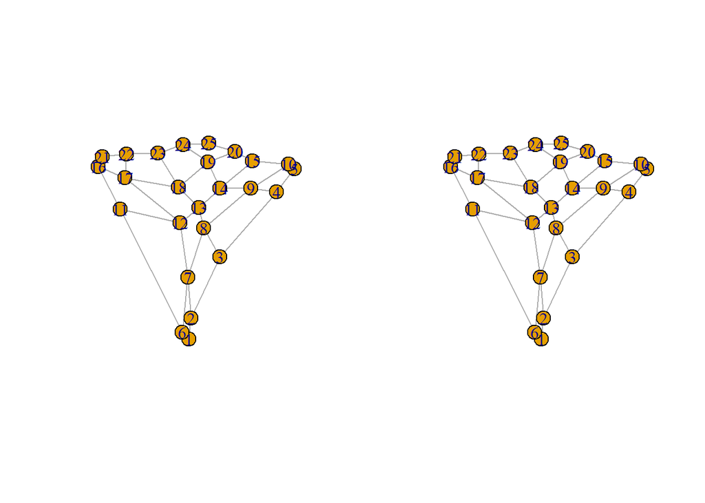

```r
par(mfrow=c(1,2))
plot(modeloTe$graficas[[10]]$g, layout=modeloTe$graficas[[10]]$miLayout)
plot(modeloTe$graficas[[15]]$g, layout=modeloTe$graficas[[15]]$miLayout)
```

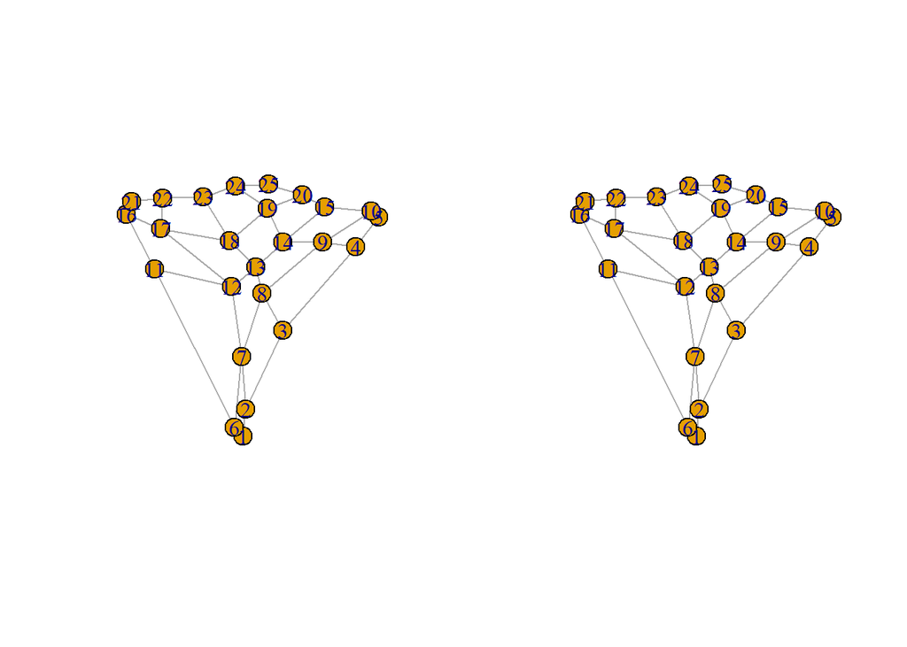

```r
par(mfrow=c(1,2))
plot(modeloTe$graficas[[20]]$g, layout=modeloTe$graficas[[20]]$miLayout)
plot(modeloTe$graficas[[25]]$g, layout=modeloTe$graficas[[25]]$miLayout)
```

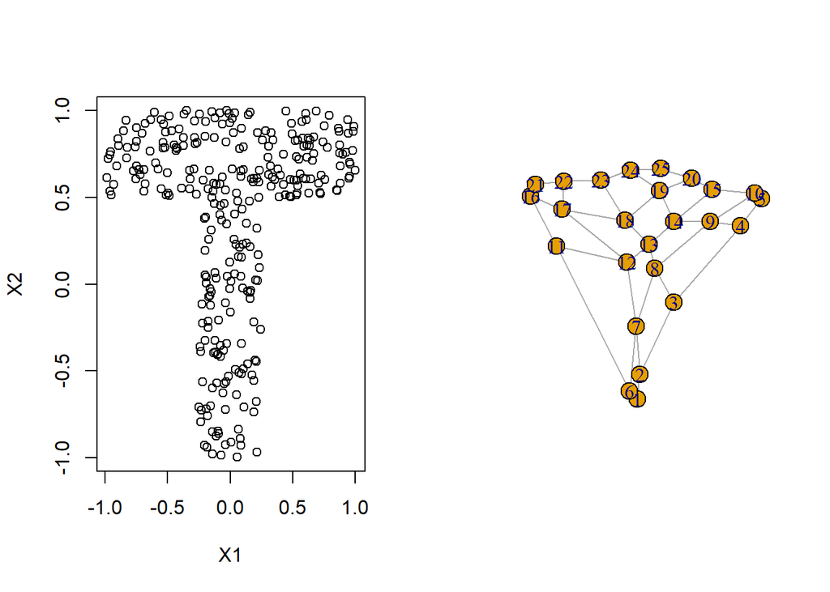

```r
par(mfrow=c(1,2))
plot(te)
plot(modeloTe$graficas[[modeloTe$epocas]]$g,
     layout=modeloTe$graficas[[modeloTe$epocas]]$miLayout)
```

- Inicialización de Grilla SOM Unidimensional - Te

```r
cantidadNodos <- 25
grillaSOM <- inicializarGrilla(cantidadNodos, forma = "lineal")
```

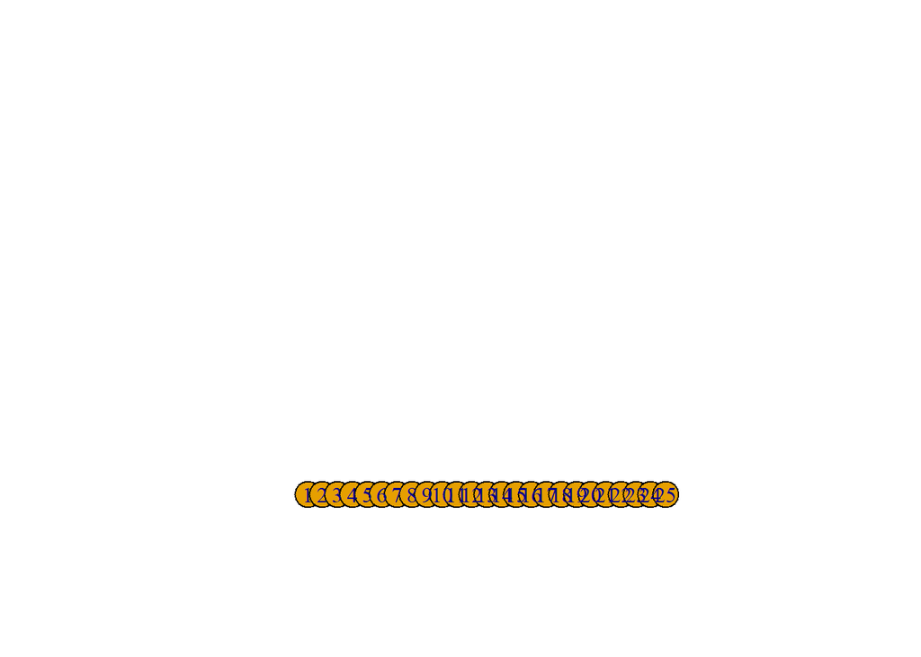

```r
g        <- grillaSOM$g
miLayout <- grillaSOM$miLayout
```

- Entrenamiento de la res SOM Unidimensional - Te

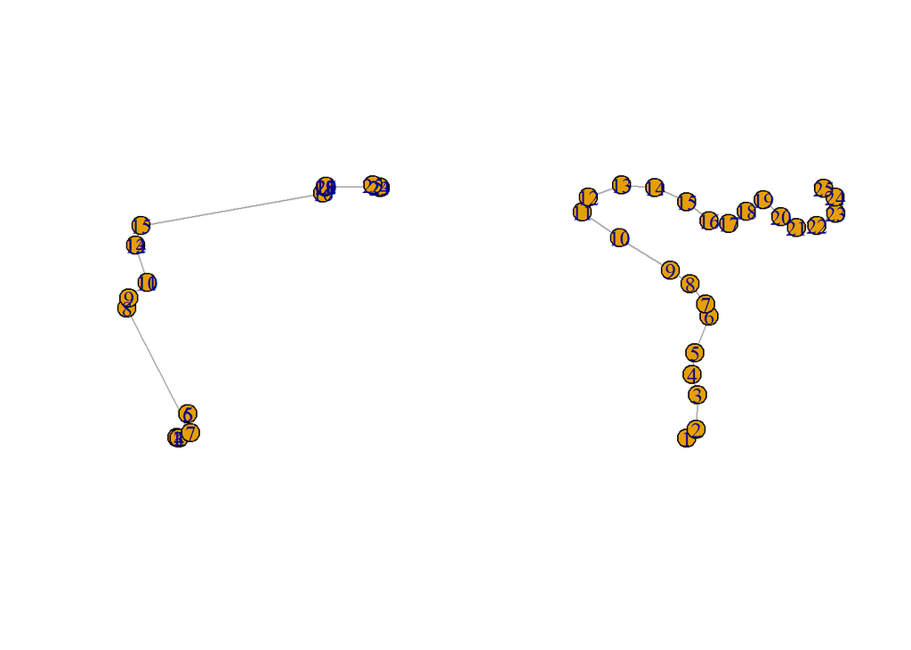

```r
datos <- te
nu <- 0.4
cantidadEpocas <- 30
cantidadNodos <- 5
entorno <- 7

if (calcular) {
  modeloTeUni <- entrenemientoSOM(datos, nu, cantidadEpocas, g, miLayout,
                                  cantidadNodos, entorno)
}

# Graficas:
par(mfrow=c(1,2))
plot(modeloTeUni$graficas[[1]]$g, layout=modeloTeUni$graficas[[1]]$miLayout)
plot(modeloTeUni$graficas[[2]]$g, layout=modeloTeUni$graficas[[2]]$miLayout)
```

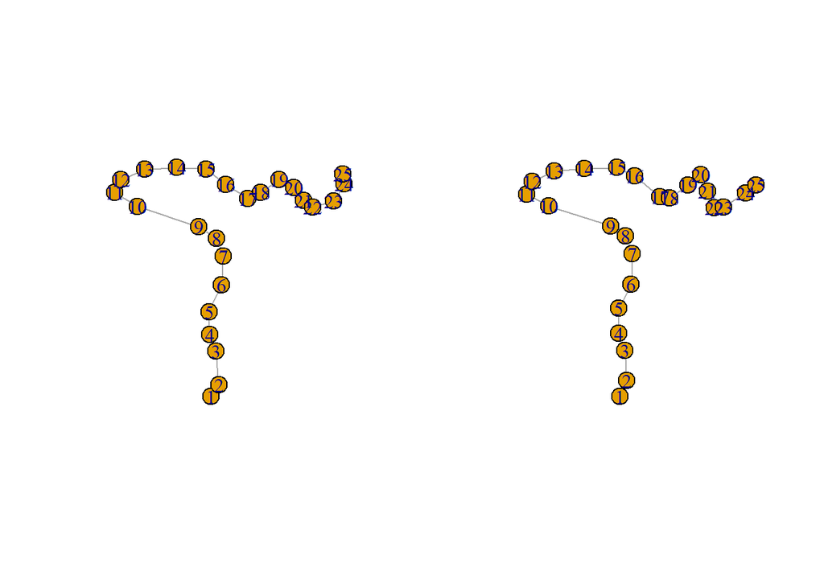

```r
par(mfrow=c(1,2))
plot(modeloTeUni$graficas[[3]]$g, layout=modeloTeUni$graficas[[3]]$miLayout)
plot(modeloTeUni$graficas[[5]]$g, layout=modeloTeUni$graficas[[5]]$miLayout)
```

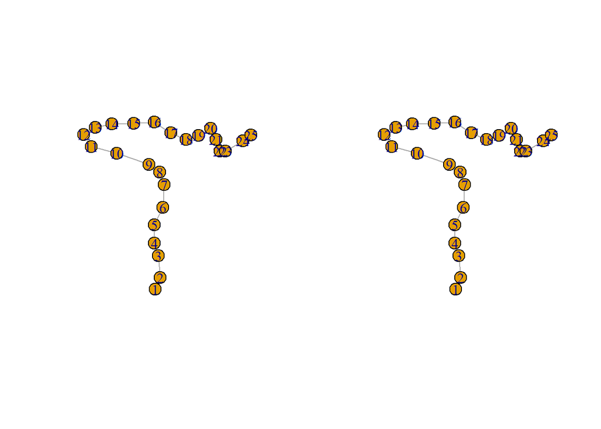

```r
par(mfrow=c(1,2))
plot(modeloTeUni$graficas[[10]]$g, layout=modeloTeUni$graficas[[10]]$miLayout)
plot(modeloTeUni$graficas[[15]]$g, layout=modeloTeUni$graficas[[15]]$miLayout)
```

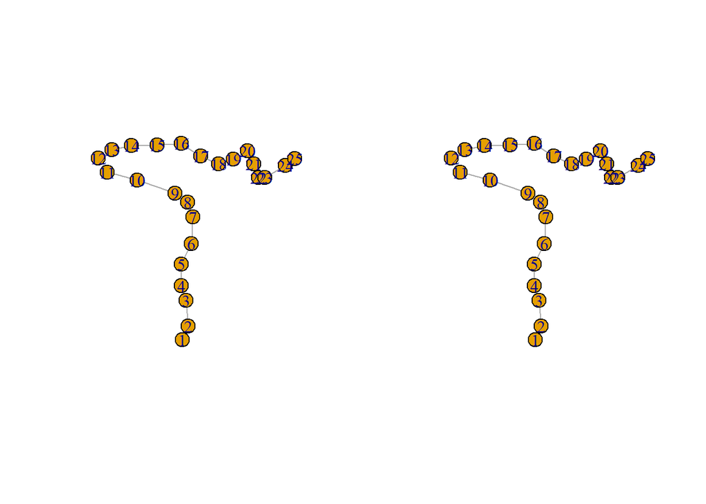

```r
par(mfrow=c(1,2))
plot(modeloTeUni$graficas[[20]]$g, layout=modeloTeUni$graficas[[20]]$miLayout)
plot(modeloTeUni$graficas[[25]]$g, layout=modeloTeUni$graficas[[25]]$miLayout)
```

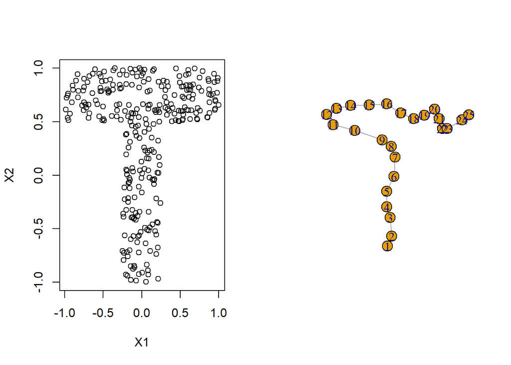

```r
par(mfrow=c(1,2))
plot(te)
plot(modeloTeUni$graficas[[modeloTeUni$epocas]]$g,
     layout=modeloTeUni$graficas[[modeloTeUni$epocas]]$miLayout)
```

Podemos observar que con la misma cantidad de neuronas, pero con la distribución lineal podemos obtener una red que se ubica por completo sobre los datos con el mismo entrenamiento.

## Ejercicio 4

- Lectura de datos

```r
clouds <- read_csv("../../PUBLICO/Encuentro 3/Práctica/data/clouds.csv", col_names = FALSE)
```

- Graficamos los datos de entrada

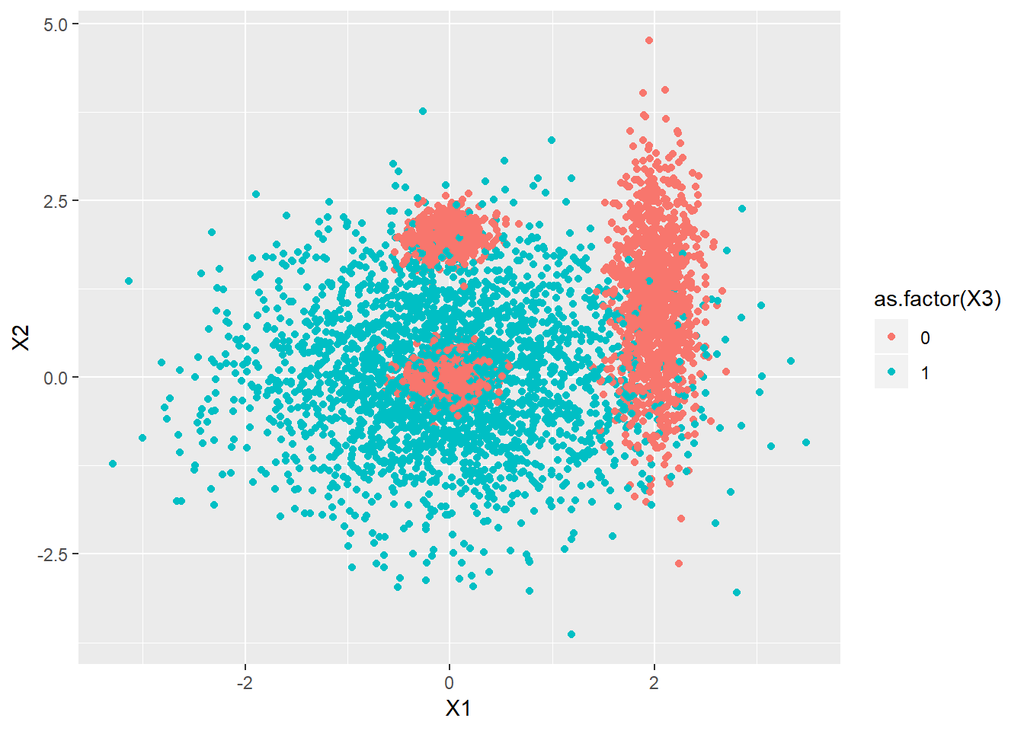

```r
ggplot(data=clouds, aes(x=X1, y=X2,color=as.factor(X3)))+geom_point()
```

- Inicialización de Grilla SOM - Clouds

Generamos una grilla SOM de 49 nodos, con esto tenemos un nodo cada 100 patrones aproximadamente.

```r
cantidadNodos <- 7
grillaSOM <- inicializarGrilla(cantidadNodos, forma = "cuadrada")
```

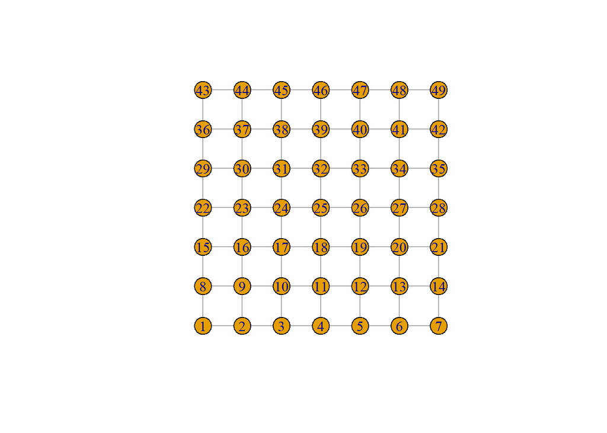

```r
g        <- grillaSOM$g
miLayout <- grillaSOM$miLayout
```

- Entrenamiento de la res SOM - Clouds

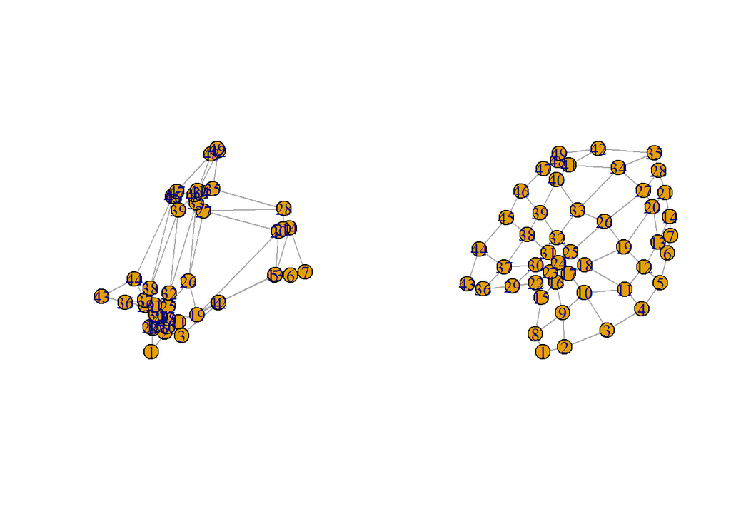

```r
datos <- clouds[,c(1,2)]
nu <- 0.4
cantidadEpocas <- 30
cantidadNodos <- 7
entorno <- 3

if (calcular) {
  modeloClouds <- entrenemientoSOM(datos, nu, cantidadEpocas, g, miLayout,
                                   cantidadNodos, entorno)
}

# Graficas:
par(mfrow=c(1,2))
plot(modeloClouds$graficas[[1]]$g, layout=modeloClouds$graficas[[1]]$miLayout)
plot(modeloClouds$graficas[[2]]$g, layout=modeloClouds$graficas[[2]]$miLayout)
```

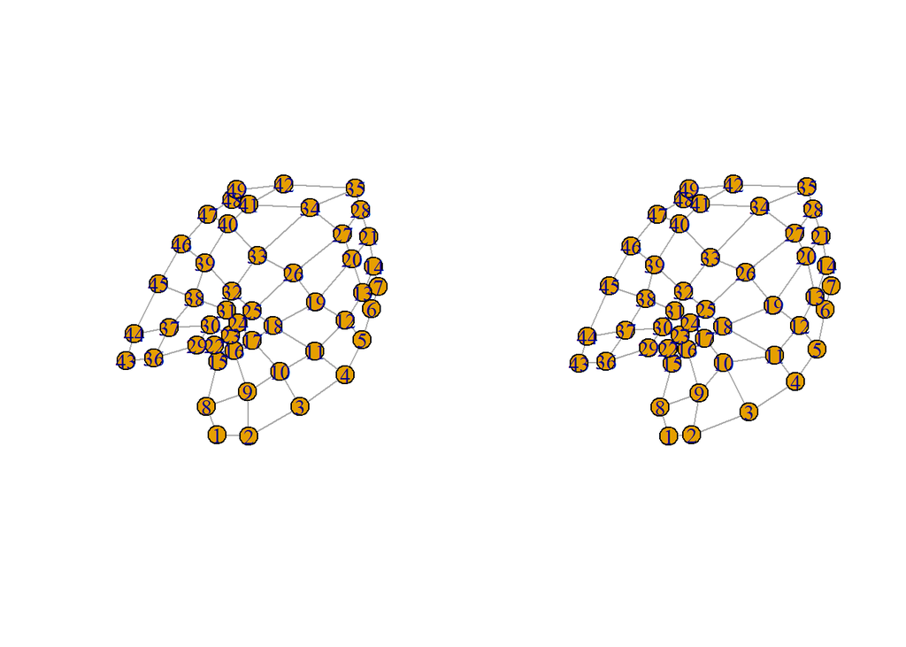

```r
par(mfrow=c(1,2))
plot(modeloClouds$graficas[[3]]$g, layout=modeloClouds$graficas[[3]]$miLayout)
plot(modeloClouds$graficas[[5]]$g, layout=modeloClouds$graficas[[5]]$miLayout)
```

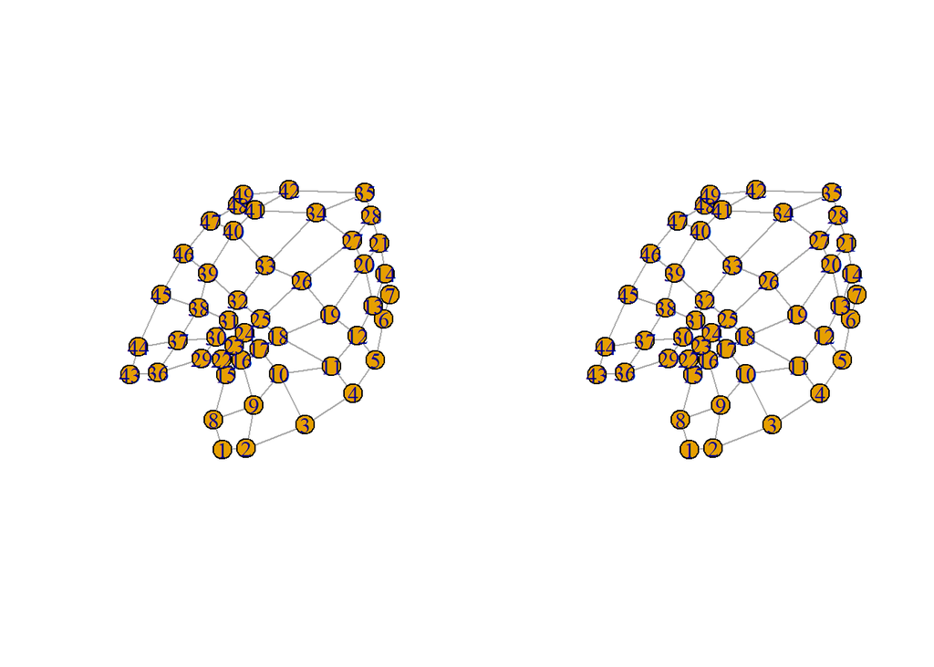

```r
par(mfrow=c(1,2))
plot(modeloClouds$graficas[[10]]$g, layout=modeloClouds$graficas[[10]]$miLayout)
plot(modeloClouds$graficas[[15]]$g, layout=modeloClouds$graficas[[15]]$miLayout)
```

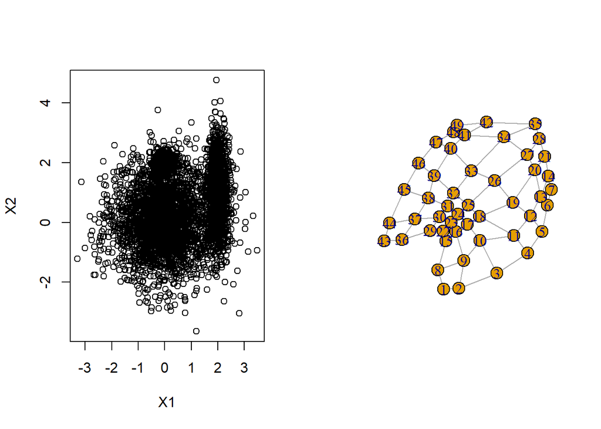

```r
par(mfrow=c(1,2))
plot(modeloClouds$graficas[[20]]$g, layout=modeloClouds$graficas[[20]]$miLayout)
plot(modeloClouds$graficas[[25]]$g, layout=modeloClouds$graficas[[25]]$miLayout)
par(mfrow=c(1,2))
plot(clouds[,c(1,2)])
plot(modeloClouds$graficas[[modeloClouds$epocas]]$g,
     layout=modeloClouds$graficas[[modeloClouds$epocas]]$miLayout)
```

- Etiquetado de neuronas

Para el etiquetado de neuronas, se evalúa la cantidad de patrones de cada clase en el entorno cercano de cada neurona. Se toma como entorno cercano un radio de la mitad de la distancia promedio de la neurona con sus vecinas.

```r
clase <- 3 # defino columna de clase
claseResultadoRed <- array(0)
miLayout <- modeloClouds$milayout
g        <- modeloClouds$g

for (i in seq(1,cantidadNodos*cantidadNodos)) {
  # calculo la distancia media a sus vecinos para definir un entorno
  vecinos <- which(g[i]==1)
  aux_1  <- miLayout[vecinos,1] - miLayout[i,1]
  aux_2  <- miLayout[vecinos,2] - miLayout[i,2]
  aux_1  <- (aux_1)^2
  aux_2  <- (aux_2)^2
  aux2 <- sqrt( aux_1 + aux_2 )
  radio <- mean(aux2) / 2

  # se clasifica el nodo con la categoría que más se repita en el entorno
  acumuladores <- array(0)
  aux_1  <- datos[,1] - miLayout[i,1]
  aux_2  <- datos[,2] - miLayout[i,2]
  aux_1  <- (aux_1)^2
  aux_2  <- (aux_2)^2
  aux2 <- sqrt( aux_1 + aux_2 )
  if(length(which(clouds[which(aux2 < radio),clase]==0)) >
     length(which(clouds[which(aux2 < radio),clase]==1))) {
    claseResultadoRed[i] <- 0
  } else {
    claseResultadoRed[i] <- 1
  }
}
```

- Clasificación con red SOM

Se asigna como clase ganadora a cada patrón a la clase de la neurona más cercana.

```r
#Ejemplo con un nuevo patrón
nuevoDato <- c(1,1)

#para el nuevo valor recorremos la red SOM y buscamos la distancia menor
aux       <- (nuevoDato - miLayout[1,])^2
distMenor <- sqrt( aux[1] + aux[2] )
nodoGanador <- 1
for (j in seq(2,cantidadNodos)) {
  # buscar menor distancia
  aux  <- (nuevoDato - miLayout[j,])^2
  aux2 <- sqrt( aux[1] + aux[2] )
  if(aux2 < distMenor) {
    distMenor   <- aux2
    nodoGanador <- j
  }
}

#clase del dato nuevo
claseResultadoRed[nodoGanador]
```

```
## [1] 0
```

```r
# Realizamos la clasificación para todos los patrones del dataset
claseResultado <- array(0)
for (i in seq(1,nrow(datos))) {
  aux_1  <- miLayout[,1] - (datos[i,1] %>% as.numeric())
  aux_2  <- miLayout[,2] - (datos[i,2] %>% as.numeric())
  aux_1  <- (aux_1)^2
  aux_2  <- (aux_2)^2
  distancias <- sqrt( aux_1 + aux_2 )
  claseResultado[i] <- claseResultadoRed[which(distancias == min(distancias))[1]]
}
```

- Visualizamos los puntos clasificados

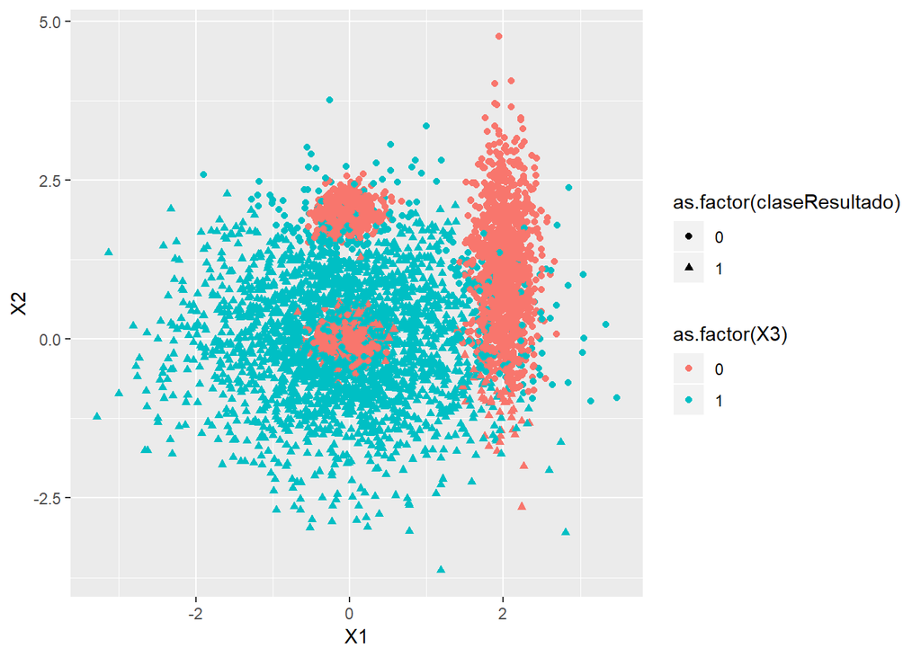

```r
ggplot(data=clouds, aes(x=X1, y=X2,color=as.factor(X3),
                        shape=as.factor(claseResultado)))+geom_point()
```

- Calculamos la tasa de aciertos

```r
aciertos <- length(which(clouds[,clase] == claseResultado))
tasa <- aciertos / nrow(clouds)
tasa
```

```
## [1] 0.86
```

Obtuvimos una tasa de un 86% de acierto, para mejorar esto se podría entrenar una red SOM con mayor numeró de neuronas.

```r
# Guardamos los modelos generados
if (calcular) {
save(modeloMerval, modeloMerval70, modeloCirculo, modeloClouds, modeloTe,
     modeloTeUni, file = "resultadosG2.RData")
}
```